# Presentation 1. - Lightning Hotspots on Earth

This presentation is about showing progress, succesful or not. On this thought, let's see first what failed:

## Localising Workflow

Due to unaccessibility to kooplex, I wanted to localise my workflow. This meant that I had to obtain data for myself, process it locally, and output the simplfied file, which will be used in the future to produce the heatmap like graphs.

### Obtaning Data

The acquisition of data turned out to be rather easy - only that the site asked for a lot of information about the user. After that, is authentication must be used to download uncompressed data, that is in netCDF4 of HDF4 format. For the downloading, the site gives a linklist in a text that is utilized by wget. As I wanted to localize my workflow on a Windows based device, I had to download wget.

Turns out that one of the flags is not good on for wget, thus I had to move to a linux based distribution. Ubuntus now come with wget, which meant that I could easy download the data - which took around 1.5 hours.

### Fileformat Issues

HDF5s are easily usable, as shown previously, h5py can easily read these, but I had HDF4s which are not in the same boat. It turned out that I had to do a conversion, which is not that reliable and works on linux only. At this point, I surrendered the thought of localised workflow while simultaneously kooplex becoming avaliable.

```python
import numpy as np
import pandas as pd
import matplotlib.pyplot as plt
import matplotlib.ticker as mticker


import sys
import os
import warnings



import pathlib
import h5py

import seaborn as sns
```

```python
import conda

conda_file_dir = conda.__file__
conda_dir = conda_file_dir.split('lib')[0]
proj_lib = os.path.join(os.path.join(conda_dir, 'share'), 'proj')
os.environ["PROJ_LIB"] = proj_lib

from mpl_toolkits.basemap import Basemap
```

```python
import cartopy.crs as ccrs
import cartopy.feature as cfeature

from cartopy.mpl.gridliner import LONGITUDE_FORMATTER, LATITUDE_FORMATTER
```

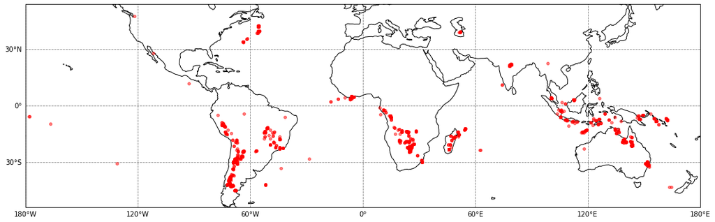

```python
#partly from
#https://ghrc.nsstc.nasa.gov/home/data-recipes/iss-lis-lightning-flash-location-quickview-using-python-30-and-gis

warnings.filterwarnings("ignore")
path = "E:/_ELTE_PHYS_MSC/3_third_semester/datascience/data/hdf5/test/"
f1 = ["ISS_LIS_SC_V1.0_20200101_NQC_17019.h5",
     "ISS_LIS_SC_V1.0_20200101_NQC_17020.h5",
     "ISS_LIS_SC_V1.0_20200101_NQC_17021.h5",
     "ISS_LIS_SC_V1.0_20200101_NQC_17022.h5",
     "ISS_LIS_SC_V1.0_20200101_NQC_17023.h5",
     "ISS_LIS_SC_V1.0_20200101_NQC_17024.h5",
     "ISS_LIS_SC_V1.0_20200101_NQC_17025.h5",
     "ISS_LIS_SC_V1.0_20200101_NQC_17026.h5",
     "ISS_LIS_SC_V1.0_20200101_NQC_17027.h5",
     "ISS_LIS_SC_V1.0_20200101_NQC_17028.h5",
     "ISS_LIS_SC_V1.0_20200101_NQC_17029.h5",
     "ISS_LIS_SC_V1.0_20200101_NQC_17030.h5",
     "ISS_LIS_SC_V1.0_20200101_NQC_17031.h5",
     "ISS_LIS_SC_V1.0_20200101_NQC_17032.h5",
     "ISS_LIS_SC_V1.0_20200101_NQC_17033.h5",
     "ISS_LIS_SC_V1.0_20200101_NQC_17034.h5"]


plt.figure(figsize=(360/10/2,4*54/10/2))
plt.title("Flashes Detected on 1st of Janurary, 2020", fontsize=32)

map = plt.axes(projection=ccrs.PlateCarree(central_longitude=0.0))
gl = map.gridlines(crs=ccrs.PlateCarree(central_longitude=0.0), draw_labels=True, linewidth=0.8,alpha=0.5,color="black",linestyle="--")

gl.ylocator = mticker.FixedLocator([-90,-60,-30,0,30,60,90])
gl.xformatter = LONGITUDE_FORMATTER
gl.yformatter = LATITUDE_FORMATTER
gl.xlabels_top=False
gl.ylabels_right=False


"""
map = Basemap(projection=ccrs.PlateCarree(central_longitude=0.0),
              llcrnrlon=-180,
              llcrnrlat=-90,
              urcrnrlon=180,
              urcrnrlat=90)
"""

for i in range(len(f1)):
    file = h5py.File(path+f1[i], 'r')
    s_set = file['orbit']['point']['lightning']['flash']
    s_set_l = np.array([list(elem) for elem in s_set])
    file.close()
    if(len(s_set_l) != 0):
        plt.plot(np.vstack(s_set_l[:,3])[:,1],
                 np.vstack(s_set_l[:,3])[:,0],
                 " ro",
                 markersize=4,
                 alpha=0.5)

map.coastlines(color="black")

plt.xlabel("Longitude [°]",fontsize=28)
plt.ylabel("Latitude [°]",fontsize=28)

plt.xlim(-180,180)
plt.ylim(-54,54)




plt.show()
```

## Simplified Output (soon)

The simplified output will be done shortly, after I convert my local files to h5 files or process data that is avaliable on kooplex. Both could be done, but one of them is a must as the simplified file will be given out due to its presumable smaller size.

## Heatmap is not the end

The heatmap just for showing results, but its not the end of the first part of this topic. A peak finder of some sort has to be applied that finds the 10 bigges hotspots on each continent. Than we can progress to part 2 which is finding some sot of cause for the existence of lightning hotspots.